# Regression Modeling Workflow

1. Introduction
2. Build a Regression Model
3. PACE: Plan
4. PACE: Analyze
5. PACE: Construct
6. PACE: Execute
7. Conclusion

[figure not shown]

# Introduction:

> **The Purpose:** This project is designed to demostrate knowledge of exploratory data analysis (EDA) and build a binomial logistic regression model and evaluate the model's performance.

> **The Goal:** To construct a binomial logistic regression model that predicts whether or not an app user will churn based on multiple variables.

[figure not shown]

# Build a Regression Model:

## PACE Stages

> - The following notebook components are labeled with the respective PACE stage: `Plan,` `Analyze,` `Construct,` and `Execute` to build this model.

# PACE: Plan

### Imports and Data Loading

```python
# Packages for numerics + dataframes
import pandas as pd
import numpy as np

# Packages for visualization
import matplotlib.pyplot as plt
import seaborn as sns

# Packages for Logistic Regression & Confusion Matrix
from sklearn.preprocessing import StandardScaler, OneHotEncoder
from sklearn.model_selection import train_test_split
from sklearn.metrics import classification_report, accuracy_score, precision_score, \
recall_score, f1_score, confusion_matrix, ConfusionMatrixDisplay
from sklearn.linear_model import LogisticRegression
```

> - Importing the dataset

```python
# Loading the dataset
df = pd.read_csv('waze_dataset.csv')
```

# PACE: Analyze

> EDA activities also include identifying missing data to help me make decisions on my exclusion or inclusion by substituting values with dataset means, medians, and other similar methods.

> Additionally, it can be useful to create variables by multiplying variables together or calculating the ratio between two variables.

## Exploring Data with EDA

> - I'll analyze and discover data, looking for correlations, missing data, potential outliers, and/or duplicates.

```python
print(df.shape)

df.info()
```

```
(14999, 13)
<class 'pandas.core.frame.DataFrame'>
RangeIndex: 14999 entries, 0 to 14998
Data columns (total 13 columns):
 #   Column                   Non-Null Count  Dtype
---  ------                   --------------  -----
 0   ID                       14999 non-null  int64
 1   label                    14299 non-null  object
 2   sessions                 14999 non-null  int64
 3   drives                   14999 non-null  int64
 4   total_sessions           14999 non-null  float64
 5   n_days_after_onboarding  14999 non-null  int64
 6   total_navigations_fav1   14999 non-null  int64
 7   total_navigations_fav2   14999 non-null  int64
 8   driven_km_drives         14999 non-null  float64
 9   duration_minutes_drives  14999 non-null  float64
 10  activity_days            14999 non-null  int64
 11  driving_days             14999 non-null  int64
 12  device                   14999 non-null  object
dtypes: float64(3), int64(8), object(2)
memory usage: 1.5+ MB
```

> - Observed the `label` column contains 700 missing values.

```python
df.head()
```

|  | ID | label | sessions | drives | total_sessions | n_days_after_onboarding | total_navigations_fav1 | total_navigations_fav2 | driven_km_drives | duration_minutes_drives | activity_days | driving_days | device |
| --- | --- | --- | --- | --- | --- | --- | --- | --- | --- | --- | --- | --- | --- |
| 0 | 0 | retained | 283 | 226 | 296.748273 | 2276 | 208 | 0 | 2628.845068 | 1985.775061 | 28 | 19 | Android |
| 1 | 1 | retained | 133 | 107 | 326.896596 | 1225 | 19 | 64 | 13715.920550 | 3160.472914 | 13 | 11 | iPhone |
| 2 | 2 | retained | 114 | 95 | 135.522926 | 2651 | 0 | 0 | 3059.148818 | 1610.735904 | 14 | 8 | Android |
| 3 | 3 | retained | 49 | 40 | 67.589221 | 15 | 322 | 7 | 913.591123 | 587.196542 | 7 | 3 | iPhone |
| 4 | 4 | retained | 84 | 68 | 168.247020 | 1562 | 166 | 5 | 3950.202008 | 1219.555924 | 27 | 18 | Android |

> The `ID` column is not needed to complete my analysis. I'll drop this column.

```python
df = df.drop('ID', axis=1)
```

> Checking the class balance of the dependent (target) variable, `label`.

```python
df['label'].value_counts(normalize=True)
```

```
label
retained    0.822645
churned     0.177355
Name: proportion, dtype: float64
```

```python
# Continuing my exploration of the data
df.describe()
```

|  | sessions | drives | total_sessions | n_days_after_onboarding | total_navigations_fav1 | total_navigations_fav2 | driven_km_drives | duration_minutes_drives | activity_days | driving_days |
| --- | --- | --- | --- | --- | --- | --- | --- | --- | --- | --- |
| count | 14999.000000 | 14999.000000 | 14999.000000 | 14999.000000 | 14999.000000 | 14999.000000 | 14999.000000 | 14999.000000 | 14999.000000 | 14999.000000 |
| mean | 80.633776 | 67.281152 | 189.964447 | 1749.837789 | 121.605974 | 29.672512 | 4039.340921 | 1860.976012 | 15.537102 | 12.179879 |
| std | 80.699065 | 65.913872 | 136.405128 | 1008.513876 | 148.121544 | 45.394651 | 2502.149334 | 1446.702288 | 9.004655 | 7.824036 |
| min | 0.000000 | 0.000000 | 0.220211 | 4.000000 | 0.000000 | 0.000000 | 60.441250 | 18.282082 | 0.000000 | 0.000000 |
| 25% | 23.000000 | 20.000000 | 90.661156 | 878.000000 | 9.000000 | 0.000000 | 2212.600607 | 835.996260 | 8.000000 | 5.000000 |
| 50% | 56.000000 | 48.000000 | 159.568115 | 1741.000000 | 71.000000 | 9.000000 | 3493.858085 | 1478.249859 | 16.000000 | 12.000000 |
| 75% | 112.000000 | 93.000000 | 254.192341 | 2623.500000 | 178.000000 | 43.000000 | 5289.861262 | 2464.362632 | 23.000000 | 19.000000 |
| max | 743.000000 | 596.000000 | 1216.154633 | 3500.000000 | 1236.000000 | 415.000000 | 21183.401890 | 15851.727160 | 31.000000 | 30.000000 |

> The following columns all seem to have outliers:

* `sessions` * `drives` * `total_sessions` * `total_navigations_fav1` * `total_navigations_fav2` * `driven_km_drives` * `duration_minutes_drives`

> All of these columns have max values that are multiple standard deviations above the 75th percentile. This could indicate outliers in these variables.

## Creating Features

> - I'll create features that may be of interest to the stakeholders and/or that are needed to address the business scenario.

#### **`km_per_driving_day`**

> - I know from earlier EDA that the churn rate correlates with distance driven per driving day in the last month. I'll engineer a feature that captures this information.

```python
# 1. Created a `km_per_driving_day` column
df['km_per_driving_day'] = df['driven_km_drives'] / df['driving_days']

# 2. Call `describe()` on the new column
df['km_per_driving_day'].describe()
```

```
count    1.499900e+04
mean              inf
std               NaN
min      3.022063e+00
25%      1.672804e+02
50%      3.231459e+02
75%      7.579257e+02
max               inf
Name: km_per_driving_day, dtype: float64
```

**Observation:**

> - Observed that some values are infinite due to there being values of zero in the `driving_days` column.
> - I'll convert these values from infinity to zero.

```python
# 1. Convert infinite values to zero
df.loc[df['km_per_driving_day']==np.inf, 'km_per_driving_day'] = 0

# 2. Confirm that it worked
df['km_per_driving_day'].describe()
```

```
count    14999.000000
mean       578.963113
std       1030.094384
min          0.000000
25%        136.238895
50%        272.889272
75%        558.686918
max      15420.234110
Name: km_per_driving_day, dtype: float64
```

#### **`professional_driver`**

> - I'll create a new, binary feature called `professional_driver` that is a 1 for users who had 60 or more drives **and** drove on 15+ days in the last month.

**Note:** The objective here is to create a new feature that separates professional drivers from other drivers.

```python
# Created a `professional_driver` column
df['professional_driver'] = np.where((df['drives'] >= 60) & (df['driving_days'] >= 15), 1, 0)
```

> - I'll perform a quick inspection of this new variable, `professional_driver`.

```python
# 1. Checking count of professionals and non-professionals
print(df['professional_driver'].value_counts())

# 2. Checking in-class churn rate
df.groupby(['professional_driver'])['label'].value_counts(normalize=True)
```

```
professional_driver
0    12405
1     2594
Name: count, dtype: int64
```

```
professional_driver  label
0                    retained    0.801202
                     churned     0.198798
1                    retained    0.924437
                     churned     0.075563
Name: proportion, dtype: float64
```

> - The churn rate for professional drivers is `7.6%`, while the churn rate for non-professionals is `19.9%`. This seems like it could add predictive signal to the model.

# PACE: Construct

After analysis and deriving variables with close relationships, it is time to begin constructing the model.

> Initially, columns were dropped based on high multicollinearity.

> Initial variable selection was based on the business objective and insights gathered from prior EDA.

## Preparing Variables

```python
df.info()
```

```
<class 'pandas.core.frame.DataFrame'>
RangeIndex: 14999 entries, 0 to 14998
Data columns (total 14 columns):
 #   Column                   Non-Null Count  Dtype
---  ------                   --------------  -----
 0   label                    14299 non-null  object
 1   sessions                 14999 non-null  int64
 2   drives                   14999 non-null  int64
 3   total_sessions           14999 non-null  float64
 4   n_days_after_onboarding  14999 non-null  int64
 5   total_navigations_fav1   14999 non-null  int64
 6   total_navigations_fav2   14999 non-null  int64
 7   driven_km_drives         14999 non-null  float64
 8   duration_minutes_drives  14999 non-null  float64
 9   activity_days            14999 non-null  int64
 10  driving_days             14999 non-null  int64
 11  device                   14999 non-null  object
 12  km_per_driving_day       14999 non-null  float64
 13  professional_driver      14999 non-null  int32
dtypes: float64(4), int32(1), int64(7), object(2)
memory usage: 1.5+ MB
```

> - I know from previous EDA that there is no evidence of a non-random cause of the 700 missing values in the `label` column, and because these observations comprise less than 5% of the data, I'll drop the rows that are missing this data.

```python
# Droping rows with missing data in `label` column
df = df.dropna(subset=['label'])
```

#### **Imputing outliers**

- Previously, I determined that seven of the variables had clear signs of containing outliers:
> - `sessions`
> - `drives`
> - `total_sessions`
> - `total_navigations_fav1`
> - `total_navigations_fav2`
> - `driven_km_drives`
> - `duration_minutes_drives`
- For this analysis, I'll impute the outlying values for these columns. Then calculate the **95th percentile** of each column and change to this value any value in the column that exceeds it.

```python
# Imputing outliers
for column in ['sessions', 'drives', 'total_sessions', 'total_navigations_fav1',
               'total_navigations_fav2', 'driven_km_drives', 'duration_minutes_drives']:
    threshold = df[column].quantile(0.95)
    df.loc[df[column] > threshold, column] = threshold
```

```python
df.describe()
```

|  | sessions | drives | total_sessions | n_days_after_onboarding | total_navigations_fav1 | total_navigations_fav2 | driven_km_drives | duration_minutes_drives | activity_days | driving_days | km_per_driving_day | professional_driver |
| --- | --- | --- | --- | --- | --- | --- | --- | --- | --- | --- | --- | --- |
| count | 14299.000000 | 14299.000000 | 14299.000000 | 14299.000000 | 14299.000000 | 14299.000000 | 14299.000000 | 14299.000000 | 14299.000000 | 14299.000000 | 14299.000000 | 14299.000000 |
| mean | 76.539688 | 63.964683 | 183.716746 | 1751.822505 | 114.562767 | 27.187216 | 3944.556684 | 1792.908045 | 15.544653 | 12.182530 | 581.942399 | 0.173998 |
| std | 67.243178 | 55.127927 | 118.719242 | 1008.663834 | 124.378550 | 36.715302 | 2218.353910 | 1224.322325 | 9.016088 | 7.833835 | 1038.254509 | 0.379121 |
| min | 0.000000 | 0.000000 | 0.220211 | 4.000000 | 0.000000 | 0.000000 | 60.441250 | 18.282082 | 0.000000 | 0.000000 | 0.000000 | 0.000000 |
| 25% | 23.000000 | 20.000000 | 90.457733 | 878.500000 | 10.000000 | 0.000000 | 2217.319909 | 840.181344 | 8.000000 | 5.000000 | 136.168003 | 0.000000 |
| 50% | 56.000000 | 48.000000 | 158.718571 | 1749.000000 | 71.000000 | 9.000000 | 3496.545617 | 1479.394387 | 16.000000 | 12.000000 | 273.301012 | 0.000000 |
| 75% | 111.000000 | 93.000000 | 253.540450 | 2627.500000 | 178.000000 | 43.000000 | 5299.972162 | 2466.928876 | 23.000000 | 19.000000 | 558.018761 | 0.000000 |
| max | 243.000000 | 200.000000 | 455.428324 | 3500.000000 | 422.000000 | 124.000000 | 8898.677337 | 4668.116791 | 31.000000 | 30.000000 | 15420.234110 | 1.000000 |

**Encoding Categorical Variables**

> - I'll change the data type of the `label` column to be binary. This change is needed to train a logistic regression model.
> - I'll assign a `0` for all `retained` users.
> - I'll assign a `1` for all `churned` users.
> - I'll then save this variable as `label2` as to not overwrite the original `label` variable.

```python
# Create binary `label2` column
df['label2'] = np.where(df['label']=='churned', 1, 0)
df[['label', 'label2']].tail()
```

|  | label | label2 |
| --- | --- | --- |
| 14994 | retained | 0 |
| 14995 | retained | 0 |
| 14996 | retained | 0 |
| 14997 | churned | 1 |
| 14998 | retained | 0 |

### Determing whether assumptions have been met

- The following are the assumptions for logistic regression:
> - Independent observations: (I'm assuming observations are independent for this project)
> - No extreme outliers: this has already been addressed previously
> - Little to no multicollinearity among X predictors will be determined below
> - Linear relationship between X and the **logit** of y (will be verified after modeling)

#### Collinearity

> - I'll now check the correlation among predictor values by first generating a correlation matrix.

```python
# Generating a correlation matrix and excluding non-numeric columns
df.corr(method='pearson', numeric_only=True)
```

|  | sessions | drives | total_sessions | n_days_after_onboarding | total_navigations_fav1 | total_navigations_fav2 | driven_km_drives | duration_minutes_drives | activity_days | driving_days | km_per_driving_day | professional_driver | label2 |
| --- | --- | --- | --- | --- | --- | --- | --- | --- | --- | --- | --- | --- | --- |
| sessions | 1.000000 | 0.996942 | 0.597190 | 0.007101 | 0.001858 | 0.008536 | 0.002996 | -0.004545 | 0.025113 | 0.020294 | -0.011569 | 0.443654 | 0.034911 |
| drives | 0.996942 | 1.000000 | 0.595286 | 0.006940 | 0.001058 | 0.009505 | 0.003445 | -0.003889 | 0.024357 | 0.019608 | -0.010989 | 0.444425 | 0.035865 |
| total_sessions | 0.597190 | 0.595286 | 1.000000 | 0.006596 | 0.000187 | 0.010371 | 0.001016 | -0.000338 | 0.015755 | 0.012953 | -0.016167 | 0.254434 | 0.024568 |
| n_days_after_onboarding | 0.007101 | 0.006940 | 0.006596 | 1.000000 | -0.002450 | -0.004968 | -0.004652 | -0.010167 | -0.009418 | -0.007321 | 0.011764 | 0.003770 | -0.129263 |
| total_navigations_fav1 | 0.001858 | 0.001058 | 0.000187 | -0.002450 | 1.000000 | 0.002866 | -0.007368 | 0.005646 | 0.010902 | 0.010419 | -0.000197 | -0.000224 | 0.052322 |
| total_navigations_fav2 | 0.008536 | 0.009505 | 0.010371 | -0.004968 | 0.002866 | 1.000000 | 0.003559 | -0.003009 | -0.004425 | 0.002000 | 0.006751 | 0.007126 | 0.015032 |
| driven_km_drives | 0.002996 | 0.003445 | 0.001016 | -0.004652 | -0.007368 | 0.003559 | 1.000000 | 0.690514 | -0.007441 | -0.009549 | 0.344811 | -0.000904 | 0.019767 |
| duration_minutes_drives | -0.004545 | -0.003889 | -0.000338 | -0.010167 | 0.005646 | -0.003009 | 0.690514 | 1.000000 | -0.007895 | -0.009426 | 0.239627 | -0.012128 | 0.040407 |
| activity_days | 0.025113 | 0.024357 | 0.015755 | -0.009418 | 0.010902 | -0.004425 | -0.007441 | -0.007895 | 1.000000 | 0.947687 | -0.397433 | 0.453825 | -0.303851 |
| driving_days | 0.020294 | 0.019608 | 0.012953 | -0.007321 | 0.010419 | 0.002000 | -0.009549 | -0.009426 | 0.947687 | 1.000000 | -0.407917 | 0.469776 | -0.294259 |
| km_per_driving_day | -0.011569 | -0.010989 | -0.016167 | 0.011764 | -0.000197 | 0.006751 | 0.344811 | 0.239627 | -0.397433 | -0.407917 | 1.000000 | -0.165966 | 0.148583 |
| professional_driver | 0.443654 | 0.444425 | 0.254434 | 0.003770 | -0.000224 | 0.007126 | -0.000904 | -0.012128 | 0.453825 | 0.469776 | -0.165966 | 1.000000 | -0.122312 |
| label2 | 0.034911 | 0.035865 | 0.024568 | -0.129263 | 0.052322 | 0.015032 | 0.019767 | 0.040407 | -0.303851 | -0.294259 | 0.148583 | -0.122312 | 1.000000 |

> - Now, I'll plot a correlation map.

[figure not shown]

```python
# Plotting a correlation heatmap
plt.figure(figsize=(15,10))
sns.heatmap(df.corr(method='pearson', numeric_only=True), vmin=-1, vmax=1, annot=True, cmap='coolwarm')
plt.title('Correlation heatmap indicates many low correlated variables', fontsize=18)
plt.show();
```

### **Observations:**

> - Predictor values that have a Pearson correlation coefficient value greater than the **absolute value of 0.7** are strongly multicollinear.
> - Only one of these variables will be used in my model.

**Multicollinear Variables:**

> - `sessions` and `drives`: 1.0
> - `driving_days` and `activity_days`: 0.95

### Creating Dummies

- Since I have selected `device` as an X variable, I will need to create dummy variables since this variable is categorical.
- This dataset has only one remaining categorical feature (`device`).
- I'll just implement the transformation directly by creating a new binary column called `device2` that encodes user devices as follows:
> - `Android` -> `0`
> - `iPhone` -> `1`

```python
# Create new `device2` variable
df['device2'] = np.where(df['device']=='Android', 0, 1)
df[['device', 'device2']].tail()
```

|  | device | device2 |
| --- | --- | --- |
| 14994 | iPhone | 1 |
| 14995 | Android | 0 |
| 14996 | iPhone | 1 |
| 14997 | iPhone | 1 |
| 14998 | iPhone | 1 |

### Model Building

**Assigning predictor variables and target**

- I'll need to drop the following variables and assign the results to `X`.
> - `label` (this is the target)
> - `label2` (this is the target)
> - `device` (this is the non-binary-encoded categorical variable)
> - `sessions` (this had high multicollinearity)
> - `driving_days` (this had high multicollinearity)

**Observation:**

> - `sessions` and `driving_days` were selected to be dropped rather than `drives` and `activity_days`. The features that were kept for modeling had slightly stronger correlations with the target variable than the features that were dropped.

```python
# Isolating predictor variables
X = df.drop(columns = ['label', 'label2', 'device', 'sessions', 'driving_days'])
```

```python
# Isolating the dependent target variable
y = df['label2']
```

### Splitting the Data

```python
# Performing the train-test split
X_train, X_test, y_train, y_test = train_test_split(X, y, stratify=y, random_state=42)
```

```python
# Use .head()
X_train.head()
```

|  | drives | total_sessions | n_days_after_onboarding | total_navigations_fav1 | total_navigations_fav2 | driven_km_drives | duration_minutes_drives | activity_days | km_per_driving_day | professional_driver | device2 |
| --- | --- | --- | --- | --- | --- | --- | --- | --- | --- | --- | --- |
| 152 | 108 | 186.192746 | 3116 | 243 | 124 | 8898.677337 | 4668.116791 | 24 | 612.305861 | 1 | 1 |
| 11899 | 2 | 3.487590 | 794 | 114 | 18 | 3286.545691 | 1780.902733 | 5 | 3286.545691 | 0 | 1 |
| 10937 | 139 | 347.106403 | 331 | 4 | 7 | 7400.838975 | 2349.305267 | 15 | 616.736581 | 0 | 0 |
| 669 | 108 | 455.428324 | 2320 | 11 | 4 | 6566.424830 | 4558.459870 | 18 | 410.401552 | 1 | 1 |
| 8406 | 10 | 89.475821 | 2478 | 135 | 0 | 1271.248661 | 938.711572 | 27 | 74.779333 | 0 | 1 |

```python
# Instantiating a logistic regression model
model = LogisticRegression(penalty='none', max_iter=400)

#Fitting the model on X-train, y_train
model.fit(X_train, y_train)
```

```
LogisticRegression(max_iter=400, penalty='none')
```

```python
# Calling the coefficients of each variable
pd.Series(model.coef_[0], index=X.columns)
```

```
drives                     0.001911
total_sessions             0.000329
n_days_after_onboarding   -0.000407
total_navigations_fav1     0.001231
total_navigations_fav2     0.000932
driven_km_drives          -0.000015
duration_minutes_drives    0.000109
activity_days             -0.106031
km_per_driving_day         0.000018
professional_driver       -0.001529
device2                   -0.001041
dtype: float64
```

```python
# Calling the model's intercept
model.intercept_
```

```
array([-0.00170705])
```

**Checking Final Assumption**

```python
# Getting the predicted probabilities of the training data
training_probabilities = model.predict_proba(X_train)
training_probabilities
```

```
array([[0.93965231, 0.06034769],
       [0.61964926, 0.38035074],
       [0.76461425, 0.23538575],
       ...,
       [0.9191012 , 0.0808988 ],
       [0.85091908, 0.14908092],
       [0.93517292, 0.06482708]])
```

```python
# 1. Copying the `X_train` dataframe and assigning to `logit_data`
logit_data = X_train.copy()

# 2. Creating a new `logit` column in the `logit_data` df
logit_data['logit'] = [np.log(prob[1] / prob[0]) for prob in training_probabilities]
```

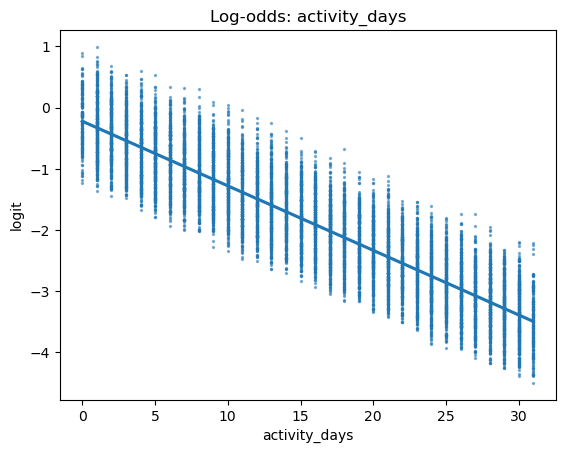

```python
# Plotting a regplot of `activity_days` log-odds
sns.regplot(x='activity_days', y='logit', data=logit_data, scatter_kws={'s': 2, 'alpha': 0.5})
plt.title('Log-odds: activity_days');
```

# PACE: Execute

### Results and Evaluation

> - I'll use the code block below to make predictions on the test data.

```python
# Generating predictions on X_test
y_preds = model.predict(X_test)
```

```python
# Scoring the model (accuracy) on the test data
model.score(X_test, y_test)
```

```
0.8237762237762237
```

### Showing Results with a Confusion Matrix

```python
# A confusion matrix using y_test and y_preds as arguments
cm = confusion_matrix(y_test, y_preds)
```

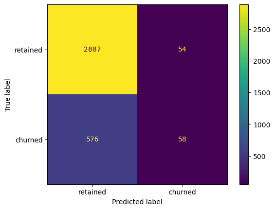

```python
disp = ConfusionMatrixDisplay(confusion_matrix=cm, display_labels=['retained', 'churned'],)
disp.plot();
```

> - I'll use the confusion matrix to compute precision and recall manually for both the `y_test` and `y_preds`.

```python
# Calculating precision manually
precision = cm[1,1] / (cm[0, 1] + cm[1, 1])
precision
```

```
0.5178571428571429
```

```python
# Calculating recall manually
recall = cm[1,1] / (cm[1, 0] + cm[1, 1])
recall
```

```
0.0914826498422713
```

```python
# Creating a classification report
target_labels = ['retained', 'churned']
print(classification_report(y_test, y_preds, target_names=target_labels))
```

```
              precision    recall  f1-score   support

    retained       0.83      0.98      0.90      2941
     churned       0.52      0.09      0.16       634

    accuracy                           0.82      3575
   macro avg       0.68      0.54      0.53      3575
weighted avg       0.78      0.82      0.77      3575
```

**Observations:**

> - The model has mediocre precision and very low recall, meaning that it makes a lot of false negative predictions and fails to capture users who will churn.
- Next, I'll Generate a bar graph of the model's coefficients for a visual representation of the importance of the model's features.

```python
# Creating a list of (column_name, coefficient) tuples
feature_importance = list(zip(X_train.columns, model.coef_[0]))

# Sorting the list by coefficient value
feature_importance = sorted(feature_importance, key=lambda x: x[1], reverse=True)
feature_importance
```

```
[('drives', 0.0019108354346885708),
 ('total_navigations_fav1', 0.0012313871249771274),
 ('total_navigations_fav2', 0.0009317647178043591),
 ('total_sessions', 0.0003287313743253515),
 ('duration_minutes_drives', 0.00010909644588511019),
 ('km_per_driving_day', 1.829734567032667e-05),
 ('driven_km_drives', -1.4884164576785548e-05),
 ('n_days_after_onboarding', -0.00040652598156536873),
 ('device2', -0.0010410315331474396),
 ('professional_driver', -0.0015287090614165093),
 ('activity_days', -0.10603117360820138)]
```

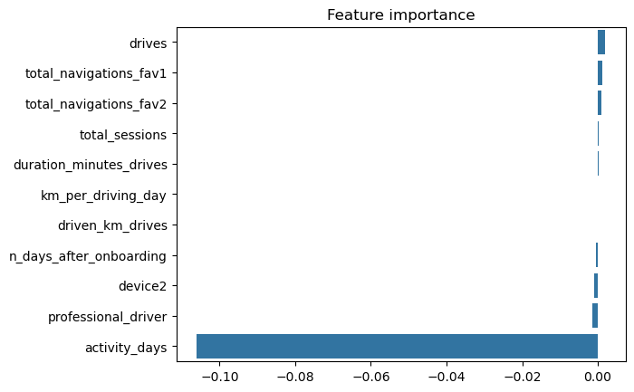

```python
# Plotting the feature importance
import seaborn as sns
sns.barplot(x=[x[1] for x in feature_importance],
            y=[x[0] for x in feature_importance],
            orient='h')
plt.title('Feature importance');
```

# Conclusion:

> - Now that I've built the regression model, the next step would be to share my findings with the leadership team.

**Variable that most influenced the model's prediction:**

> `activity_days` was by far the most important feature in the model. It had a negative correlation with user churn. This was not surprising, as this variable was very strongly correlated with `driving_days`, which was known from EDA to have a negative correlation with churn.

**Variables expected to be stronger predictors:**

> In previous EDA, user churn rate increased as the values in `km_per_driving_day` increased. The correlation heatmap here in this notebook revealed this variable to have the strongest positive correlation with churn of any of the predictor variables by a relatively large margin. In the model, it was the second-least-important variable.

**Recommended model use:**

> The model is not a strong enough predictor, as made clear by its poor recall score. However, if the model will be used to guide further exploratory efforts, then it can have value.

**Options to improve this model:**

> New features could be engineered to try to generate a better predictive signal. In the case of this model, one of the engineered features (`professional_driver`) was the third-most-predictive predictor. It could also be helpful to scale the predictor variables, and/or to reconstruct the model with different combinations of predictor variables to reduce noise from unpredictive features.

**Potential additional features:**

> It would be helpful to have drive-level information for each user (such as drive times, geographic locations, etc.). It would probably also be helpful to have more granular data to know how users interact with the app. For example, how often do they report or confirm road hazard alerts? Finally, it could be helpful to know the monthly count of unique starting and ending locations each driver inputs.